# Chapter 4

## Lagrangian Polynomial

The first thing in Chapter 4 of substance is the use of Lagrangian polynomials to fit data points. Recall that for $n+1$ points, we can write a unique $n^{th}$ order polymial

$$y = P(x) = y_0 L_0(x) + y_1 L_1(x) + ... + y_n L_n(x)$$

where

$$L_k(x) = \frac{(x - x_0)(x - x_1)...(x
- x_{k-1})(x - x_{k+1})...(x - x_n)}{(x_k - x_0)(x_k - x_1)...(x_k -
x_{k-1})(x_k - x_{k+1})...(x_k - x_n)}.$$

Let’s use R to calculate $P(x)$ for some data set.

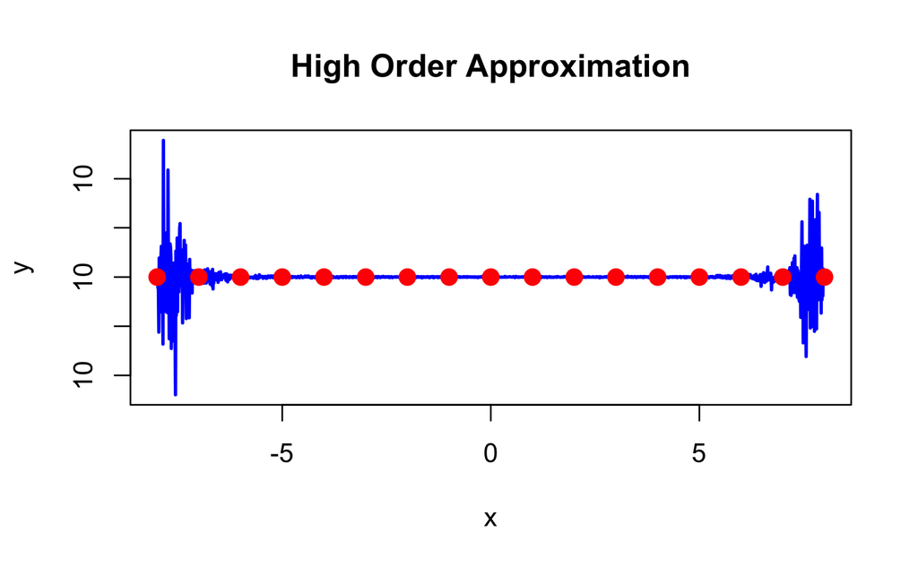

```r
#x are the x data for the polynomial
#y are the y data for the polynomial

makeLagrange <- function(x,y){
  subPolys <- list()
  for(i in 1:length(x)){
    Lk_num <- paste0("(x - ",x[-i],")", collapse = "*")
    Lk_denom <- paste0("(",x[i]," - ",x[-i],")", collapse = "*")
    subPolys[[i]] <- paste0(y[i],"*",Lk_num,"/(",Lk_denom,")")
  }
  lagrangePolyBody <- paste(unlist(subPolys),collapse=" + ")

  eval(parse(text = paste0('function(x) {',lagrangePolyBody,'}')))
}



### Book Figure 4.12

lPoly <- makeLagrange(-8:8,rep(10,17))
xVals <- seq(-8,8,by=0.01)
plot(xVals,lPoly(xVals), type="l", xlab="x", ylab="y", main = "High Order Approximation", lwd = 2, col="blue")
points(-8:8, rep(10,17), col="red", cex=2, pch=20)
```

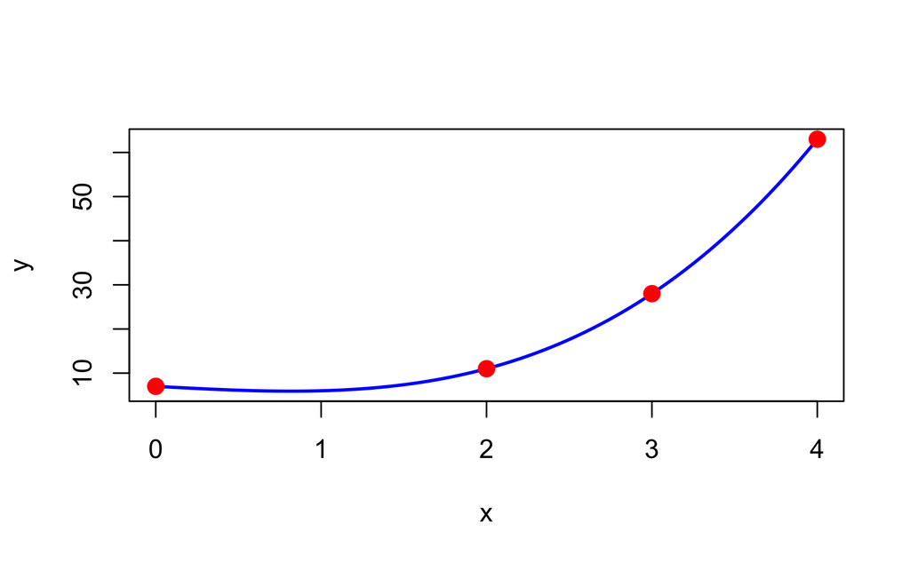

```r
lPoly2 <- makeLagrange(c(0, 2, 3, 4), c(7, 11, 28, 63))
xVals2 <- seq(0,4,by=0.05)
plot(xVals2,lPoly2(xVals2), type = "l", xlab="x", ylab="y", col="blue", lwd=2)
points(c(0, 2, 3, 4), c(7, 11, 28, 63), col="red", cex=2, pch=20)
```

## Divided Difference Tables

First, let’s make some simple data for us to use with our divided differences. We’ll take a look at a data set without noise, and then add some noise into it. We will use 20 data points. Our data will follow the polynomial

$$y = 2 x^3 - 5 x^2 + x + 5$$

```r
# x data
set.seed(19624)
x <- sort(runif(20,-5,5)) #note the sorting
y <- 2*x^3 - 5*x^2 + x + 5

# y with (small) noise
y.noise <- y + rnorm(20,0,0.2)
```

We will be using the `diff` command to find our divided differences. There are two options for the `diff` command: `lag` and `differences`. `lag` specifies how far apart the two elements are in a vector to be differenced. The `differences` argument specifies if you want first differences, second differences, etc. Let’s use the the command to get our table for the clean table:

```r
first <- diff(y)/diff(x)
second <- diff(first)/diff(x,lag=2)
third <- diff(second)/diff(x,lag=3)
fourth <- diff(third)/diff(x,lag=4)

data.frame(first, second = c(0,second), third = c(0,0,third), fourth = c(0,0,0,fourth))
```

[output not shown]

It’s pretty clear that third divided difference is a constant, thus suggesting that a $3^{rd}$ order polynomial would fit our data. So our divided difference table gave us the correct answer. Let’s do the same thing with the noisy data:

```r
first <- diff(y.noise)/diff(x)
second <- diff(first)/diff(x,lag=2)
third <- diff(second)/diff(x,lag=3)
fourth <- diff(third)/diff(x,lag=4)

data.frame(first, second = c(0,second), third = c(0,0,third), fourth = c(0,0,0,fourth))
```

[output not shown]

At this point, we see that with our noisy data, we still have some fairly large differences. Let’s take a few more divided differences and see if things get better:

```r
fifth <- diff(fourth)/diff(x,lag=5)
sixth<- diff(fifth)/diff(x,lag=6)
seventh<- diff(sixth)/diff(x,lag=7)
fourth
fifth
sixth
seventh
```

[output not shown]

Even with a small amount of noise, our differences are not going to zero, i.e., the errors are propagating through the table. It becomes difficult to tell what order is appropriate. One thing we can do is look at plots of the divided differences.

```r
par(mfrow = c(3,2))
plot(first, type="l",lwd=2,col="blue")
plot(second, type="l",lwd=2,col="blue")
plot(third, type="l",lwd=2,col="blue")
plot(fourth, type="l",lwd=2,col="blue")
plot(fifth, type="l",lwd=2,col="blue")
plot(sixth, type="l",lwd=2,col="blue")
```

[output not shown]

## Splines

As discussed in class, smoothing splines are piecewise polynomial functions of some order. Probably the most common order used is a $3^{rd}$ order (cubic) polynomial. The polynomials are joined at points called knots (i.e., two consecutive knots define the domain of one of the cubic polynomials). More formally, for some sequence of $(n+1)$ knots $k_0, k_1, ..., k_n$ where $k_0 = \min(x)$ and $k_n = \max(x)$, then curves $S_1, S_2, ... S_n$ given by
$$S_1 = a_1+b_1 x + c_1 x^2 + d_1 x^3 \qquad x \in
[k_0,k_1) \\
S_2 = a_2+b_2 x + c_2 x^2 + d_2 x^3 \qquad x \in [k_1,k_2) \\
\vdots \\
S_n = a_n+b_n x + c_n x^2 + d_n x^3 \qquad x \in [k_{n-1},k_n)$$

define the spline $S(x)$. Because we wish the spline to be smooth, we require that $S_i'(k_i) = S_{i+1}'(k_{i})$. Optionally (among many options), it can also be required that $S_i''(k_i) = S_{i+1}''(k_{i})$. At the endpoints $k_0,k_n$, we can impose special boundary conditions. A “natural” spline is one where we require that $S_0''(k_0)=S_n''(k_n) = 0$, i.e., the first derivative stays constant at the exterior boundary. If we happen to have information about the first derivative at the endpoints, given by $f'(k_0)$ and $f'(k_n)$, then we can create a “clamped” spline by setting $S'_1(k_0) = f'(k_0)$ and $S_n'(k_n) = f'(k_n)$.

The fit of a spline is often assessed using a *penalized* log-likelihood. The penalized log-likelihood is defined by

$$\mathcal{L} = (y-f)'W(y-f) + \lambda
c' \Sigma c$$

where $W$ is a weights matrix (if you want certain observations to be more important), $y$ are the data, $f$ are the modeled values, $\lambda$ is a smoothing parameter, $c$ are the coefficients of penalized regression, and $\Sigma$ is a variance-covariance matrix of the spline functions. The important thing to note is the first term $(y-f)'W(y-f)$ is just a least-squares regression that can be weighted by $W$. The second thing is that $\lambda$ controls **how much smoothing** you wish to do. If $\lambda = 0$, we get a least-squares fit for each segment $S_i$ of our spline. If insteads, we use the `spar` flag (**s**moothing **par**ameter) and set it to 1, we get a highly smoothed spline.

Let’s try out a smoothing spline in R using a larger data set based on the same polynomial we used earlier:

```r
set.seed(8652)
x <- sort(runif(200,-5,5)) #note the sorting
y <- 2*x^3 - 5*x^2 + x + 5

# y with (small) noise
y.noise <- y + rnorm(200,0,50)

plot(x, y.noise, ylab="y")
```

[output not shown]

Okay, we have a fairly noisy data set. Let’s try the function `smooth.spline` to find a nice fit:

```r
s1 <- smooth.spline(x,y.noise)
m1 <- predict(s1, x)

plot(x, y.noise, ylab="y", main = "Default Smoothed Spline")
points(m1, col="red", type="l", lwd = 2)
```

[output not shown]

Okay, that’s not bad!!! Right out of the box, we didn’t need to do much to get a pretty smoothed spline. Let’s play with some of the options we have, namely, the amount of smoothing we wish to do and where the knots are. First, let’s get some info from the spline object:

```r
s1$spar #how much smothing was done?
s1$fit$knot #see how many knots and where, note these are scaled between xmin and xmax
```

[output not shown]

Now that we know a bit about the “out-of-the-box” spline, we can mess around with it some. Let’s try a spline with just a few knots, say 6, and not a lot of smoothing.

```r
s2 <- smooth.spline(x,y.noise, nknots = 6, spar = 0.1)
m2 <- predict(s2, x)

plot(x, y.noise, ylab="y", main="Spline with 6 knots")
points(m2, col="red", type="l", lwd = 2)
abline(v = unique(s2$fit$knot) * diff(range(x)) + min(x), col="blue", lty = 2, lwd = 2)
```

[output not shown]

Note that the knots are not even spaced! How do you think they are spaced?

```r
table(cut(x, unique(s2$fit$knot) * diff(range(x)) + min(x), include.lowest=T))
```

[output not shown]

Let’s set the knots ourselves:

```r
s3 <- smooth.spline(x,y.noise, all.knots = seq(0,1,length=6), spar = 0.1)
m3 <- predict(s3, x)

plot(x, y.noise, ylab="y", main="Spline with 6 evenly spaced knots")
points(m3, col="red", type="l", lwd = 2)
abline(v = unique(s3$fit$knot) * diff(range(x)) + min(x), col="blue", lty = 2, lwd = 2)
```

[output not shown]

Finally, let’s compare 3 splines where we either have no smoothing, some smoothing, or full smoothing and we use a small number of knots, 4.

```r
s4 <- smooth.spline(x,y.noise, all.knots = seq(0,1,length=4), spar = 0)
m4 <- predict(s4, x)

s5 <- smooth.spline(x,y.noise, all.knots = seq(0,1,length=4), spar = 0.25)
m5 <- predict(s5, x)

s6 <- smooth.spline(x,y.noise, all.knots = seq(0,1,length=4), spar = 1)
m6 <- predict(s6, x)

plot(x, y.noise, ylab="y", main="Splines with 4 evenly spaced knots and different smoothing")
points(m4, col="red", type="l", lwd = 2)
points(m5, col="green", type="l", lwd = 2)
points(m6, type="l",lwd=2)
abline(v = unique(s4$fit$knot) * diff(range(x)) + min(x), col="blue", lty = 2, lwd = 2)
legend("bottomright", legend = c("0", "0.25", "1"), lty = 1, col = c("red","green","black"), title = expression(lambda))
```

[output not shown]

Why do we get a straight line when $\lambda = 1$? Why don’t we see three distinct segments to the line?